# Day 2

# Overview

Functional and speed. What do you define as speed? What kind of speed is important to you?

[Benchmarks Game](http://benchmarksgame.alioth.debian.org/u64q/compare.php?lang=ghc&lang2=python3)

[Comparison of F# and C# in the wild](http://fsharpforfunandprofit.com/posts/cycles-and-modularity-in-the-wild/)

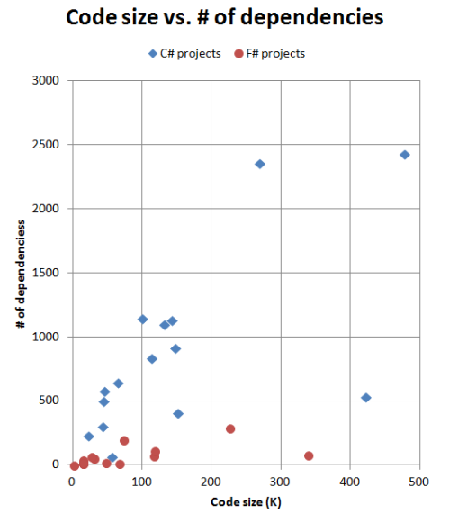

Code vs Dependencies

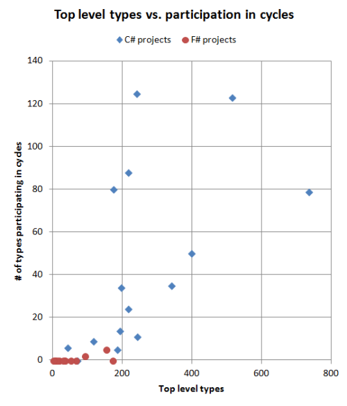

Top vs Cycles

# Essentially

```csharp
public class CustomerName
{
    public CustomerName(string firstName,
       string middleInitial, string lastName)
    {
        this.FirstName = firstName;
        this.MiddleInitial = middleInitial;
        this.LastName = lastName;
    }

    public string FirstName { get; private set; }
    public string MiddleInitial { get; private set; }
    public string LastName { get; private set; }
}
```

# VS

```fsharp
type CustomerName(firstName, middleInitial, lastName) =
    member this.FirstName = firstName
    member this.MiddleInitial = middleInitial
    member this.LastName = lastName
```

```haskell
data CustomerName = CustomerName
    {firstName     :: Text
    ,middleInitial :: Text
    ,lastName      :: Text }
```

# Rest of Course

What is interest? We'll start doing things in an additive way. More interested in data processing type things? Or maybe network?

# Haskell

- .hs
- .lhs
- ghci
- :info (:i)
- :type (:t)
- :r (reload)
- :load (load script name)
- :edit (uses editor)
- :? (list all commands)

# Info Meld

- [GHCI](http://ghc.io/)
- [FP Complete](https://www.fpcomplete.com/school/starting-with-haskell)
- [What I Wish I Knew](http://dev.stephendiehl.com/hask/) - try Text
- [Functional Programming](https://github.com/caiorss/Functional-Programming)
- [LYAH](http://learnyouahaskell.com/chapters)
- [EdX](https://courses.edx.org/courses/DelftX/FP101x/3T2014/info)
  - [Lecture repo](https://github.com/fptudelft/FP101x-Content)
- [Cheat Sheet](http://cheatsheet.codeslower.com/CheatSheet.pdf)
- [Parallel and Concurrent Programming in Haskell](http://chimera.labs.oreilly.com/books/1230000000929/index.html)

# Get our feet wet

We use Λ or λ

```haskell
λ > 2 + 15
λ > 59 * 100
λ > 5 / 2
λ > (-4) + 5

λ > True && False
False
λ > not (True && True)
False

λ > 5 == 5
True
λ > 5 /= 5
False
λ > "hello" == "hello"

λ > 5 == "hello"
ERROR!
```

# Basic Types

- Bool
- Char
- String
- Int (fixed-precision)
- Integer (arbitrary-precision)
- Float

# Expressions

> Expressions have a value, while statements do not. If you can pass it as an argument to a function, it's an expression. If you can't, it's a statement. Control flow constructs in C-derived languages are generally statements (you can't pass an 'if {}' block as a function parameter). Consequently, those languages tend to provide an expression form for 'if' (like the ternary operator). Of course, the whole point of many functional languages is that everything has a value, and that functions are first-class values, which means that everything is an expression. Statements usually appear in imperative languages, where you wish to write commands that don't necessarily return a value. - Lambda the Ultimate

# Operation vs Denotational

- Operational semantics: Translates code to abstract machine statements
- Denotational semantics: Translates code to mathematical expressions

# Simple Function

Ticks for infix, ' identify strict vs non.

```bash
echo "doubleMe x = x + x" > example.hs
ghci
```

```haskell
λ > :l example.hs

λ > doubleSmall x = if x > 100 then x else x * 2
λ > conanO'Brien = "It's a-me, Conan O'Brien!"

λ > factorial n = product [1..n]
λ > average ns = sum ns `div` length ns
```

# Prefix vs Infix

Almost everything in Haskell is a function, and every function can be prefix or infix:

```haskell
λ > 1 + 1
λ > (+) 1 1
λ > min 9 10
λ > 9 `min` 10
λ > read "10" * 2

abs
mod
even
```

# Prelude

[Hackage](https://hackage.haskell.org/) and [Stackage](http://www.stackage.org/)

What is [Prelude](https://hackage.haskell.org/package/base-4.8.0.0/docs/Prelude.html)?

Functional is almost as much about lists as functions.

[Lists](https://hackage.haskell.org/package/base-4.8.0.0/docs/Prelude.html#g:13)

[figure not shown]

List Monster

# Lists

If you're indexing you're probably doing it wrong.

- head
- tail
- take
- drop
- length (O(n))
- sum
- product
- (++)
- reverse

# Reverse

```haskell
rev [] = []
```

```haskell
rev xs = last xs : rev (init xs)
rev xs = rev (tail xs) ++ [head xs]
rev (x:xs) = rev xs ++ [x]
```

# Last

Implement last

last xs = head ( drop (lengt xs - 1) xs) last xs = xs !! (length xs - 1)

# Comprehensions

### Simple List Comprehension

```haskell
> [x^2 | x <- [1..10]]
[1,4,9,16,25,36,49,64,81,100]

>  [ odd x | x <- [1..9]]
[True,False,True,False,True,False,True,False,True]
```

### Comprehensions with multiple generators

Comprehensions with multiple generators, separated by commas. The generators are x <- [1, 2, 4] and y <- [4,5].

```haskell
> [(x, y) | x <- [1, 2, 4], y <- [4,5]]
[(1,4),(1,5),(2,4),(2,5),(4,4),(4,5)]

> [(x-y, x+y) | x <- [1, 2, 4], y <- [4,5]]
[(-3,5),(-4,6),(-2,6),(-3,7),(0,8),(-1,9)]

> [(x/y, x*y) | x <- [1, 2, 4], y <- [4,5]]
[(0.25,4.0),(0.2,5.0),(0.5,8.0),(0.4,10.0),(1.0,16.0),(0.8,20.0)]
```

### Function Inside List Comprehension

```haskell
> let f x y = sqrt(x^2 + y^2)

> [ f x y | x <- [1, 2, 4], y <- [4,5]]
[4.123105625617661,5.0990195135927845,4.47213595499958,5.385164807134504,5.656854249492381,6.4031242374328485]
```

### Comprehension with Guards

Guards or filter is a boolean expression that removes elements that would otherwise have been included in the list comprehension. They restricts the values produced by earlier generators.

Even number sequence

```haskell
> [x | x <- [1..10], even x]
[2,4,6,8,10]

>  [x | x <- [1,5,12,3,23,11,7,2], x>10]
[12,23,11]

> [(x,y) | x <- [1,3,5], y <- [2,4,6], x<y]
[(1,2),(1,4),(1,6),(3,4),(3,6),(5,6)]
```

Odd Number sequence

```haskell
> [x | x <- [1..10], odd x]
[1,3,5,7,9]
```

Number factors and Prime Numbers

```haskell
> let factors n = [ x | x <- [1..n], mod n x == 0]
>
> factors 15
[1,3,5,15]
>
> factors 10
[1,2,5,10]
>
> factors 100
[1,2,4,5,10,20,25,50,100]
>
> factors 17
[1,17]
> factors 19
[1,19]

> let prime n = factors n == [1, n]
>
> prime 17
True
> prime 19
True
> prime 20
False
>

{- Get all prime numbers until number n -}

> let primes_n n = [ x | x <- [1..n], prime x]
>
> primes_n 10
[2,3,5,7]
> primes_n 100
[2,3,5,7,11,13,17,19,23,29,31,37,41,43,47,53,59,61,67,71,73,79,83,89,97]
>
```

# Ranges

```haskell
λ > [1..20]
[1,2,3,4,5,6,7,8,9,10,11,12,13,14,15,16,17,18,19,20]
λ > ['a'..'z']
"abcdefghijklmnopqrstuvwxyz"
λ > ['K'..'Z']
"KLMNOPQRSTUVWXYZ"

λ > [2,4..20]
[2,4,6,8,10,12,14,16,18,20]
λ > [3,6..20]
[3,6,9,12,15,18]

data MyDataType = Foo | Bar | Baz deriving (Enum, Show)
λ > succ Foo
λ > pred Baz
```

# Tuples

Which right triangle that has integers for all sides and all sides equal to or smaller than 10 has a perimeter of 24? First, let's try generating all triangles with sides equal to or smaller than 10:

. . . hint

```haskell
λ > let triangles = [ (a,b,c) | c <- [1..10], b <- [1..10], a <- [1..10] ]
```

# Practice

[Haskell Basics](https://www.fpcomplete.com/school/starting-with-haskell/introduction-to-haskell/1-haskell-basics)

# End

BELOW HERE ARE NOTES AND THINGS I HAVENT QUITE FINISHED YET

# Fixity

[output not shown]

No definition, infixl 9 assumed.

# Example

```
(^^!) :: (Num a, Integral b) => a -> b -> a
a ^^! b = a ^ b

(^^^) :: (Num a, Integral b) => a -> b -> a
a ^^^ b = a ^ b

infixl 9 ^^!
infixr 9 ^^^

data Test = Test String deriving (Eq, Show)

(>:) :: Test -> Test -> Test
(Test a) >: (Test b) = Test $ "(" ++ a ++ " >: " ++ b ++ ")"

infixr 6 >:

(<:) :: Test -> Test -> Test
(Test a) <: (Test b) = Test $ "(" ++ a ++ " <: " ++ b ++ ")"

infixl 6 <:

(?:) :: Test -> Test -> Test
(Test a) ?: (Test b) = Test $ "(" ++ a ++ " ?: " ++ b ++ ")"

infix 6 ?:


main = do
    print $ show $ 4 ^^! 3 ^^! 2
    print $ show $ 4 ^^^ 3 ^^^ 2

    print $ (Test "1") >: (Test "2") >: (Test "4")
    print $ (Test "1") <: (Test "2") <: (Test "4")
    print $ (Test "1") ?: ((Test "2") ?: (Test "4"))
```

# Folds

The recursion for foldr f x ys where ys = [y1,y2,...,yk] looks like

`f y1 (f y2 (... (f yk x) ...))`

whereas the recursion for foldl f x ys looks like

`f (... (f (f x y1) y2) ...) yk`

# Function Names

Lowercase Type uppercase

different namespaces

Mild hungarian, xs is list of xs, two ss, list of lists.

White space is significant: Same columns

# Function Application

Usually `f(a,b) + c d` would mean: f with a and b params, c space d mult

Haskell:

```
f a b + c * d
```

Function application binds stronger than others.

```
f a + b is f(a) + b
```

# Math vs Haskell

| Math | Haskell |
| --- | --- |
| f(x) | f x |
| f(x,y) | f x y |
| f(g(x)) | f (g x) |
| f(x,g(y)) | f x (g y) |
| f(x)g(y) | f x * g y |

. . . Lighter syntax

# Types

# Algebraic Data Types

thing :: type

Lists: Polymorphic

[False, True, False] :: [Bool]['a','b','c'] :: [Char][['a'],['a','b']] :: [[Char]]

Tuples:

(Flase, True) :: (Bool, Bool) (False, 'a', True) :: (Bool, Char, Bool) (False, ('a',False)) :: (Bool, (Char, Bool))

# Function

Mapping of one type to another:

not :: Bool -> Bool isDigit :: Char -> Bool

# Currying - CLOSURES!

Arrow is right associative. Application is left associative. All functions have one param. Any with more actually return functions.

```
mult :: Int -> Int -> Int -> Int
// Is actually
mult :: Int -> (Int -> (Int -> Int))

mult 3 2 5
// Is actually
(((mult 3) 2) 5)
```

is actually

- return a function that multiplies by 3 and 2 other values
- return a function that multiplies by 3, 2 and one other value
- multiply 3, 2, and 5

# Why Currying?

Partial application.

try it

# Parentheses

2 ^ 3 * 4 2 * 3 + 4 * 5 2 + 3 * 4 ^ 5

# A

(2 ^ 3) * 4 (2 * 3) + (4 * 5) 2 + (3 * (4 ^ 5))

# Error?

N = a 'div' length xs where a = 10 xs = [1,2,3,4]

# A

n = a `div` length xs where a = 10 xs = [1,2,3,4]

# Last

last xs = head ( drop (lengt xs - 1) xs) last xs = xs !! (length xs - 1)